# Risk Factor Analysis

## Outcome Variable

**Outcome Variable:** ever_wasted

## Predictor Variables

**Intervention Variable:** meducyrs

**Adjustment Set:**

- arm
- W_mage
- feducyrs
- hhwealth_quart
- W_mhtcm
- W_gagebrth
- W_birthwt
- W_birthlen
- W_nrooms
- W_nchldlt5
- impfloor
- impsan
- safeh20
- delta_W_mage
- delta_feducyrs
- delta_hhwealth_quart
- delta_W_mhtcm
- delta_W_gagebrth
- delta_W_birthwt
- delta_W_birthlen
- delta_W_nrooms
- delta_W_nchldlt5
- delta_impfloor
- delta_impsan
- delta_safeh20

## Stratifying Variables

The analysis was stratified on these variable(s):

- agecat
- studyid
- country

## Data Summary

| agecat | studyid | country | meducyrs | ever_wasted | n_cell | n |
| --- | --- | --- | --- | --- | --- | --- |
| 0-24 months | ki0047075b-MAL-ED | BANGLADESH | Low | 0 | 46 | 213 |
| 0-24 months | ki0047075b-MAL-ED | BANGLADESH | Low | 1 | 24 | 213 |
| 0-24 months | ki0047075b-MAL-ED | BANGLADESH | Medium | 0 | 44 | 213 |
| 0-24 months | ki0047075b-MAL-ED | BANGLADESH | Medium | 1 | 21 | 213 |
| 0-24 months | ki0047075b-MAL-ED | BANGLADESH | High | 0 | 59 | 213 |
| 0-24 months | ki0047075b-MAL-ED | BANGLADESH | High | 1 | 19 | 213 |
| 0-24 months | ki0047075b-MAL-ED | BRAZIL | Low | 0 | 55 | 232 |
| 0-24 months | ki0047075b-MAL-ED | BRAZIL | Low | 1 | 8 | 232 |
| 0-24 months | ki0047075b-MAL-ED | BRAZIL | Medium | 0 | 82 | 232 |
| 0-24 months | ki0047075b-MAL-ED | BRAZIL | Medium | 1 | 8 | 232 |
| 0-24 months | ki0047075b-MAL-ED | BRAZIL | High | 0 | 76 | 232 |
| 0-24 months | ki0047075b-MAL-ED | BRAZIL | High | 1 | 3 | 232 |
| 0-24 months | ki0047075b-MAL-ED | INDIA | Low | 0 | 33 | 220 |
| 0-24 months | ki0047075b-MAL-ED | INDIA | Low | 1 | 43 | 220 |
| 0-24 months | ki0047075b-MAL-ED | INDIA | Medium | 0 | 44 | 220 |
| 0-24 months | ki0047075b-MAL-ED | INDIA | Medium | 1 | 37 | 220 |
| 0-24 months | ki0047075b-MAL-ED | INDIA | High | 0 | 39 | 220 |
| 0-24 months | ki0047075b-MAL-ED | INDIA | High | 1 | 24 | 220 |
| 0-24 months | ki0047075b-MAL-ED | NEPAL | Low | 0 | 69 | 225 |
| 0-24 months | ki0047075b-MAL-ED | NEPAL | Low | 1 | 27 | 225 |
| 0-24 months | ki0047075b-MAL-ED | NEPAL | Medium | 0 | 51 | 225 |
| 0-24 months | ki0047075b-MAL-ED | NEPAL | Medium | 1 | 25 | 225 |
| 0-24 months | ki0047075b-MAL-ED | NEPAL | High | 0 | 40 | 225 |
| 0-24 months | ki0047075b-MAL-ED | NEPAL | High | 1 | 13 | 225 |
| 0-24 months | ki0047075b-MAL-ED | PERU | Low | 0 | 93 | 301 |
| 0-24 months | ki0047075b-MAL-ED | PERU | Low | 1 | 11 | 301 |
| 0-24 months | ki0047075b-MAL-ED | PERU | Medium | 0 | 95 | 301 |
| 0-24 months | ki0047075b-MAL-ED | PERU | Medium | 1 | 12 | 301 |
| 0-24 months | ki0047075b-MAL-ED | PERU | High | 0 | 87 | 301 |
| 0-24 months | ki0047075b-MAL-ED | PERU | High | 1 | 3 | 301 |

[output cut: 438 more lines]

The following strata were considered:

- agecat: 0-24 months, studyid: ki0047075b-MAL-ED, country: BANGLADESH
- agecat: 0-24 months, studyid: ki0047075b-MAL-ED, country: BRAZIL
- agecat: 0-24 months, studyid: ki0047075b-MAL-ED, country: INDIA
- agecat: 0-24 months, studyid: ki0047075b-MAL-ED, country: NEPAL
- agecat: 0-24 months, studyid: ki0047075b-MAL-ED, country: PERU
- agecat: 0-24 months, studyid: ki0047075b-MAL-ED, country: SOUTH AFRICA
- agecat: 0-24 months, studyid: ki0047075b-MAL-ED, country: TANZANIA, UNITED REPUBLIC OF
- agecat: 0-24 months, studyid: ki1000108-CMC-V-BCS-2002, country: INDIA
- agecat: 0-24 months, studyid: ki1000108-IRC, country: INDIA
- agecat: 0-24 months, studyid: ki1000109-EE, country: PAKISTAN
- agecat: 0-24 months, studyid: ki1000304b-SAS-CompFeed, country: INDIA
- agecat: 0-24 months, studyid: ki1000304b-SAS-FoodSuppl, country: INDIA
- agecat: 0-24 months, studyid: ki1017093-NIH-Birth, country: BANGLADESH
- agecat: 0-24 months, studyid: ki1017093b-PROVIDE, country: BANGLADESH
- agecat: 0-24 months, studyid: ki1017093c-NIH-Crypto, country: BANGLADESH
- agecat: 0-24 months, studyid: ki1066203-TanzaniaChild2, country: TANZANIA, UNITED REPUBLIC OF
- agecat: 0-24 months, studyid: ki1112895-Guatemala BSC, country: GUATEMALA
- agecat: 0-24 months, studyid: ki1113344-GMS-Nepal, country: NEPAL
- agecat: 0-24 months, studyid: ki1119695-PROBIT, country: BELARUS
- agecat: 0-24 months, studyid: ki1126311-ZVITAMBO, country: ZIMBABWE
- agecat: 0-24 months, studyid: ki1135781-COHORTS, country: GUATEMALA
- agecat: 0-24 months, studyid: ki1135781-COHORTS, country: INDIA
- agecat: 0-24 months, studyid: ki1135781-COHORTS, country: PHILIPPINES
- agecat: 0-24 months, studyid: ki1148112-LCNI-5, country: MALAWI
- agecat: 0-24 months, studyid: kiGH5241-JiVitA-3, country: BANGLADESH
- agecat: 0-24 months, studyid: kiGH5241-JiVitA-4, country: BANGLADESH
- agecat: 0-6 months, studyid: ki0047075b-MAL-ED, country: BANGLADESH
- agecat: 0-6 months, studyid: ki0047075b-MAL-ED, country: BRAZIL
- agecat: 0-6 months, studyid: ki0047075b-MAL-ED, country: INDIA
- agecat: 0-6 months, studyid: ki0047075b-MAL-ED, country: NEPAL
- agecat: 0-6 months, studyid: ki0047075b-MAL-ED, country: PERU
- agecat: 0-6 months, studyid: ki0047075b-MAL-ED, country: SOUTH AFRICA
- agecat: 0-6 months, studyid: ki0047075b-MAL-ED, country: TANZANIA, UNITED REPUBLIC OF
- agecat: 0-6 months, studyid: ki1000108-CMC-V-BCS-2002, country: INDIA
- agecat: 0-6 months, studyid: ki1000108-IRC, country: INDIA
- agecat: 0-6 months, studyid: ki1000109-EE, country: PAKISTAN
- agecat: 0-6 months, studyid: ki1000304b-SAS-CompFeed, country: INDIA
- agecat: 0-6 months, studyid: ki1000304b-SAS-FoodSuppl, country: INDIA
- agecat: 0-6 months, studyid: ki1017093-NIH-Birth, country: BANGLADESH
- agecat: 0-6 months, studyid: ki1017093b-PROVIDE, country: BANGLADESH
- agecat: 0-6 months, studyid: ki1017093c-NIH-Crypto, country: BANGLADESH
- agecat: 0-6 months, studyid: ki1066203-TanzaniaChild2, country: TANZANIA, UNITED REPUBLIC OF
- agecat: 0-6 months, studyid: ki1112895-Guatemala BSC, country: GUATEMALA
- agecat: 0-6 months, studyid: ki1113344-GMS-Nepal, country: NEPAL
- agecat: 0-6 months, studyid: ki1119695-PROBIT, country: BELARUS
- agecat: 0-6 months, studyid: ki1126311-ZVITAMBO, country: ZIMBABWE
- agecat: 0-6 months, studyid: ki1135781-COHORTS, country: GUATEMALA
- agecat: 0-6 months, studyid: ki1135781-COHORTS, country: INDIA
- agecat: 0-6 months, studyid: ki1135781-COHORTS, country: PHILIPPINES
- agecat: 0-6 months, studyid: ki1148112-LCNI-5, country: MALAWI
- agecat: 0-6 months, studyid: kiGH5241-JiVitA-3, country: BANGLADESH
- agecat: 0-6 months, studyid: kiGH5241-JiVitA-4, country: BANGLADESH
- agecat: 6-24 months, studyid: ki0047075b-MAL-ED, country: BANGLADESH
- agecat: 6-24 months, studyid: ki0047075b-MAL-ED, country: BRAZIL
- agecat: 6-24 months, studyid: ki0047075b-MAL-ED, country: INDIA
- agecat: 6-24 months, studyid: ki0047075b-MAL-ED, country: NEPAL
- agecat: 6-24 months, studyid: ki0047075b-MAL-ED, country: PERU
- agecat: 6-24 months, studyid: ki0047075b-MAL-ED, country: SOUTH AFRICA
- agecat: 6-24 months, studyid: ki0047075b-MAL-ED, country: TANZANIA, UNITED REPUBLIC OF
- agecat: 6-24 months, studyid: ki1000108-CMC-V-BCS-2002, country: INDIA
- agecat: 6-24 months, studyid: ki1000108-IRC, country: INDIA
- agecat: 6-24 months, studyid: ki1000109-EE, country: PAKISTAN
- agecat: 6-24 months, studyid: ki1000304b-SAS-CompFeed, country: INDIA
- agecat: 6-24 months, studyid: ki1000304b-SAS-FoodSuppl, country: INDIA
- agecat: 6-24 months, studyid: ki1017093-NIH-Birth, country: BANGLADESH
- agecat: 6-24 months, studyid: ki1017093b-PROVIDE, country: BANGLADESH
- agecat: 6-24 months, studyid: ki1017093c-NIH-Crypto, country: BANGLADESH
- agecat: 6-24 months, studyid: ki1066203-TanzaniaChild2, country: TANZANIA, UNITED REPUBLIC OF
- agecat: 6-24 months, studyid: ki1112895-Guatemala BSC, country: GUATEMALA
- agecat: 6-24 months, studyid: ki1113344-GMS-Nepal, country: NEPAL
- agecat: 6-24 months, studyid: ki1119695-PROBIT, country: BELARUS
- agecat: 6-24 months, studyid: ki1126311-ZVITAMBO, country: ZIMBABWE
- agecat: 6-24 months, studyid: ki1135781-COHORTS, country: GUATEMALA
- agecat: 6-24 months, studyid: ki1135781-COHORTS, country: INDIA
- agecat: 6-24 months, studyid: ki1135781-COHORTS, country: PHILIPPINES
- agecat: 6-24 months, studyid: ki1148112-LCNI-5, country: MALAWI
- agecat: 6-24 months, studyid: kiGH5241-JiVitA-3, country: BANGLADESH
- agecat: 6-24 months, studyid: kiGH5241-JiVitA-4, country: BANGLADESH

### Dropped Strata

Some strata were dropped due to rare outcomes:

- agecat: 0-24 months, studyid: ki0047075b-MAL-ED, country: BRAZIL
- agecat: 0-24 months, studyid: ki0047075b-MAL-ED, country: PERU
- agecat: 0-24 months, studyid: ki0047075b-MAL-ED, country: TANZANIA, UNITED REPUBLIC OF
- agecat: 0-6 months, studyid: ki0047075b-MAL-ED, country: BRAZIL
- agecat: 0-6 months, studyid: ki0047075b-MAL-ED, country: PERU
- agecat: 0-6 months, studyid: ki0047075b-MAL-ED, country: TANZANIA, UNITED REPUBLIC OF
- agecat: 0-6 months, studyid: ki1000109-EE, country: PAKISTAN
- agecat: 0-6 months, studyid: ki1000304b-SAS-FoodSuppl, country: INDIA
- agecat: 0-6 months, studyid: ki1112895-Guatemala BSC, country: GUATEMALA
- agecat: 0-6 months, studyid: ki1148112-LCNI-5, country: MALAWI
- agecat: 6-24 months, studyid: ki0047075b-MAL-ED, country: BRAZIL
- agecat: 6-24 months, studyid: ki0047075b-MAL-ED, country: PERU
- agecat: 6-24 months, studyid: ki0047075b-MAL-ED, country: TANZANIA, UNITED REPUBLIC OF
- agecat: 6-24 months, studyid: ki1112895-Guatemala BSC, country: GUATEMALA

## Methods Detail

We’re interested in the causal parameters $E[Y_a]$ for all values of $a \in \mathcal{A}$. These parameters represent the mean outcome if, possibly contrary to fact, we intervened to set all units to have $A=a$. Under the randomization and positivity assumptions, these are identified by the statistical parameters $\psi_a=E_W[E_{Y|A,W}(Y|A=a,W)]$. In addition, we’re interested in the mean of $Y$, $E[Y]$ under no intervention (the observed mean). We will estimate these parameters by using SuperLearner to fit the relevant likelihood factors – $E_{Y|A,W}(Y|A=a,W)$ and $p(A=a|W)$, and then updating our likelihood fit using a joint TMLE.

For unadjusted analyses ($W=\{\}$), initial likelihoods were estimated using Lrnr_glm to estimate the simple $E(Y|A)$ and Lrnr_mean to estimate $p(A)$. For adjusted analyses, a small library containing Lrnr_glmnet, Lrnr_xgboost, and Lrnr_mean was used.

Having estimated these parameters, we will then use the delta method to estimate relative risks and attributable risks relative to a prespecified baseline level of $A$.

# Results Detail

## Results Plots

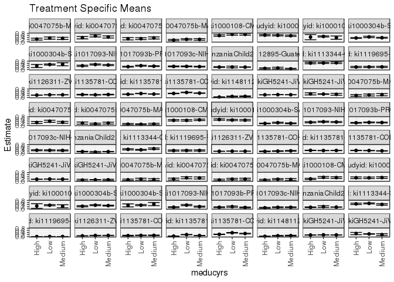

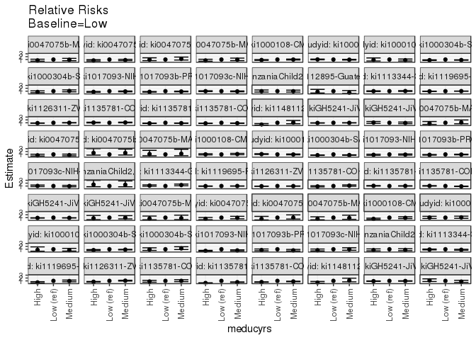

[figure not shown]

[figure not shown]

## Results Table

### Parameter: TSM

| agecat | studyid | country | intervention_level | baseline_level | estimate | ci_lower | ci_upper |
| --- | --- | --- | --- | --- | --- | --- | --- |
| 0-24 months | ki0047075b-MAL-ED | BANGLADESH | Low | NA | 0.3507037 | 0.2460230 | 0.4553844 |
| 0-24 months | ki0047075b-MAL-ED | BANGLADESH | Medium | NA | 0.3186635 | 0.2112327 | 0.4260944 |
| 0-24 months | ki0047075b-MAL-ED | BANGLADESH | High | NA | 0.2469233 | 0.1563591 | 0.3374875 |
| 0-24 months | ki0047075b-MAL-ED | INDIA | Low | NA | 0.5625517 | 0.4577420 | 0.6673614 |
| 0-24 months | ki0047075b-MAL-ED | INDIA | Medium | NA | 0.4543338 | 0.3517989 | 0.5568687 |
| 0-24 months | ki0047075b-MAL-ED | INDIA | High | NA | 0.3819849 | 0.2711894 | 0.4927805 |
| 0-24 months | ki0047075b-MAL-ED | NEPAL | Low | NA | 0.2934461 | 0.2046808 | 0.3822113 |
| 0-24 months | ki0047075b-MAL-ED | NEPAL | Medium | NA | 0.3613999 | 0.2596723 | 0.4631274 |
| 0-24 months | ki0047075b-MAL-ED | NEPAL | High | NA | 0.2883494 | 0.1771212 | 0.3995776 |
| 0-24 months | ki0047075b-MAL-ED | SOUTH AFRICA | Low | NA | 0.2306927 | 0.1683303 | 0.2930551 |
| 0-24 months | ki0047075b-MAL-ED | SOUTH AFRICA | Medium | NA | 0.2211192 | 0.1422800 | 0.2999585 |
| 0-24 months | ki0047075b-MAL-ED | SOUTH AFRICA | High | NA | 0.1572151 | 0.0937985 | 0.2206317 |
| 0-24 months | ki1000108-CMC-V-BCS-2002 | INDIA | Low | NA | 0.7079741 | 0.6293797 | 0.7865685 |
| 0-24 months | ki1000108-CMC-V-BCS-2002 | INDIA | Medium | NA | 0.7032241 | 0.6251815 | 0.7812667 |
| 0-24 months | ki1000108-CMC-V-BCS-2002 | INDIA | High | NA | 0.5942725 | 0.5235601 | 0.6649848 |
| 0-24 months | ki1000108-IRC | INDIA | Low | NA | 0.6116088 | 0.5535033 | 0.6697143 |
| 0-24 months | ki1000108-IRC | INDIA | Medium | NA | 0.5765944 | 0.5145372 | 0.6386517 |
| 0-24 months | ki1000108-IRC | INDIA | High | NA | 0.6296076 | 0.5660137 | 0.6932016 |
| 0-24 months | ki1000109-EE | PAKISTAN | Low | NA | 0.5063641 | 0.4523032 | 0.5604250 |
| 0-24 months | ki1000109-EE | PAKISTAN | Medium | NA | 0.3911044 | 0.2317190 | 0.5504899 |
| 0-24 months | ki1000109-EE | PAKISTAN | High | NA | 0.4419493 | 0.1917306 | 0.6921679 |
| 0-24 months | ki1000304b-SAS-CompFeed | INDIA | Low | NA | 0.4603036 | 0.3949510 | 0.5256561 |
| 0-24 months | ki1000304b-SAS-CompFeed | INDIA | Medium | NA | 0.3809765 | 0.3360790 | 0.4258739 |
| 0-24 months | ki1000304b-SAS-CompFeed | INDIA | High | NA | 0.3584648 | 0.3192502 | 0.3976794 |
| 0-24 months | ki1000304b-SAS-FoodSuppl | INDIA | Low | NA | 0.4817013 | 0.4279264 | 0.5354762 |
| 0-24 months | ki1000304b-SAS-FoodSuppl | INDIA | Medium | NA | 0.5093760 | 0.3627151 | 0.6560368 |
| 0-24 months | ki1000304b-SAS-FoodSuppl | INDIA | High | NA | 0.3448643 | 0.1983460 | 0.4913825 |
| 0-24 months | ki1017093-NIH-Birth | BANGLADESH | Low | NA | 0.4850322 | 0.4326626 | 0.5374019 |
| 0-24 months | ki1017093-NIH-Birth | BANGLADESH | Medium | NA | 0.4349834 | 0.3806922 | 0.4892745 |
| 0-24 months | ki1017093-NIH-Birth | BANGLADESH | High | NA | 0.3630701 | 0.3079054 | 0.4182348 |

[output cut: 162 more lines]

### Parameter: E(Y)

| agecat | studyid | country | intervention_level | baseline_level | estimate | ci_lower | ci_upper |
| --- | --- | --- | --- | --- | --- | --- | --- |
| 0-24 months | ki0047075b-MAL-ED | BANGLADESH | NA | NA | 0.3004695 | 0.2387555 | 0.3621835 |
| 0-24 months | ki0047075b-MAL-ED | INDIA | NA | NA | 0.4727273 | 0.4066048 | 0.5388497 |
| 0-24 months | ki0047075b-MAL-ED | NEPAL | NA | NA | 0.2888889 | 0.2295338 | 0.3482440 |
| 0-24 months | ki0047075b-MAL-ED | SOUTH AFRICA | NA | NA | 0.1955128 | 0.1514355 | 0.2395901 |
| 0-24 months | ki1000108-CMC-V-BCS-2002 | INDIA | NA | NA | 0.6139410 | 0.5644682 | 0.6634139 |
| 0-24 months | ki1000108-IRC | INDIA | NA | NA | 0.6560976 | 0.6100625 | 0.7021326 |
| 0-24 months | ki1000109-EE | PAKISTAN | NA | NA | 0.4907162 | 0.4401862 | 0.5412462 |
| 0-24 months | ki1000304b-SAS-CompFeed | INDIA | NA | NA | 0.4150694 | 0.3581204 | 0.4720184 |
| 0-24 months | ki1000304b-SAS-FoodSuppl | INDIA | NA | NA | 0.4712919 | 0.4233811 | 0.5192026 |
| 0-24 months | ki1017093-NIH-Birth | BANGLADESH | NA | NA | 0.4775641 | 0.4383415 | 0.5167867 |
| 0-24 months | ki1017093b-PROVIDE | BANGLADESH | NA | NA | 0.3514286 | 0.3160364 | 0.3868207 |
| 0-24 months | ki1017093c-NIH-Crypto | BANGLADESH | NA | NA | 0.3311346 | 0.2976093 | 0.3646598 |
| 0-24 months | ki1066203-TanzaniaChild2 | TANZANIA, UNITED REPUBLIC OF | NA | NA | 0.2367980 | 0.2197367 | 0.2538593 |
| 0-24 months | ki1112895-Guatemala BSC | GUATEMALA | NA | NA | 0.1063830 | 0.0703329 | 0.1424331 |
| 0-24 months | ki1113344-GMS-Nepal | NEPAL | NA | NA | 0.5909850 | 0.5515796 | 0.6303903 |
| 0-24 months | ki1119695-PROBIT | BELARUS | NA | NA | 0.2565984 | 0.1993515 | 0.3138454 |
| 0-24 months | ki1126311-ZVITAMBO | ZIMBABWE | NA | NA | 0.2346433 | 0.2276029 | 0.2416837 |
| 0-24 months | ki1135781-COHORTS | GUATEMALA | NA | NA | 0.2564297 | 0.2328823 | 0.2799770 |
| 0-24 months | ki1135781-COHORTS | INDIA | NA | NA | 0.3329911 | 0.3209071 | 0.3450751 |
| 0-24 months | ki1135781-COHORTS | PHILIPPINES | NA | NA | 0.4036125 | 0.3861835 | 0.4210415 |
| 0-24 months | ki1148112-LCNI-5 | MALAWI | NA | NA | 0.0798526 | 0.0612199 | 0.0984853 |
| 0-24 months | kiGH5241-JiVitA-3 | BANGLADESH | NA | NA | 0.2582816 | 0.2518151 | 0.2647481 |
| 0-24 months | kiGH5241-JiVitA-4 | BANGLADESH | NA | NA | 0.3204728 | 0.2971300 | 0.3438156 |
| 0-6 months | ki0047075b-MAL-ED | BANGLADESH | NA | NA | 0.2206573 | 0.1648355 | 0.2764790 |
| 0-6 months | ki0047075b-MAL-ED | INDIA | NA | NA | 0.3136364 | 0.2521871 | 0.3750856 |
| 0-6 months | ki0047075b-MAL-ED | NEPAL | NA | NA | 0.1777778 | 0.1277101 | 0.2278455 |
| 0-6 months | ki0047075b-MAL-ED | SOUTH AFRICA | NA | NA | 0.1025641 | 0.0688457 | 0.1362825 |
| 0-6 months | ki1000108-CMC-V-BCS-2002 | INDIA | NA | NA | 0.5190217 | 0.4679041 | 0.5701394 |
| 0-6 months | ki1000108-IRC | INDIA | NA | NA | 0.5439024 | 0.4956326 | 0.5921723 |
| 0-6 months | ki1000304b-SAS-CompFeed | INDIA | NA | NA | 0.2199336 | 0.1753445 | 0.2645227 |
| 0-6 months | ki1017093-NIH-Birth | BANGLADESH | NA | NA | 0.3569132 | 0.3192325 | 0.3945938 |
| 0-6 months | ki1017093b-PROVIDE | BANGLADESH | NA | NA | 0.2585714 | 0.2261125 | 0.2910304 |
| 0-6 months | ki1017093c-NIH-Crypto | BANGLADESH | NA | NA | 0.2585752 | 0.2273844 | 0.2897660 |
| 0-6 months | ki1066203-TanzaniaChild2 | TANZANIA, UNITED REPUBLIC OF | NA | NA | 0.1395641 | 0.1256566 | 0.1534717 |
| 0-6 months | ki1113344-GMS-Nepal | NEPAL | NA | NA | 0.2954925 | 0.2589234 | 0.3320615 |
| 0-6 months | ki1119695-PROBIT | BELARUS | NA | NA | 0.2497780 | 0.1917926 | 0.3077635 |
| 0-6 months | ki1126311-ZVITAMBO | ZIMBABWE | NA | NA | 0.1809503 | 0.1745333 | 0.1873674 |
| 0-6 months | ki1135781-COHORTS | GUATEMALA | NA | NA | 0.2007612 | 0.1765324 | 0.2249900 |
| 0-6 months | ki1135781-COHORTS | INDIA | NA | NA | 0.2511554 | 0.2398221 | 0.2624886 |
| 0-6 months | ki1135781-COHORTS | PHILIPPINES | NA | NA | 0.2355453 | 0.2204685 | 0.2506222 |
| 0-6 months | kiGH5241-JiVitA-3 | BANGLADESH | NA | NA | 0.1763390 | 0.1707116 | 0.1819665 |
| 0-6 months | kiGH5241-JiVitA-4 | BANGLADESH | NA | NA | 0.1126043 | 0.0962730 | 0.1289355 |
| 6-24 months | ki0047075b-MAL-ED | BANGLADESH | NA | NA | 0.1384615 | 0.0898601 | 0.1870630 |
| 6-24 months | ki0047075b-MAL-ED | INDIA | NA | NA | 0.2657005 | 0.2053824 | 0.3260185 |
| 6-24 months | ki0047075b-MAL-ED | NEPAL | NA | NA | 0.1545455 | 0.1066715 | 0.2024194 |
| 6-24 months | ki0047075b-MAL-ED | SOUTH AFRICA | NA | NA | 0.1389961 | 0.0967835 | 0.1812087 |
| 6-24 months | ki1000108-CMC-V-BCS-2002 | INDIA | NA | NA | 0.2654155 | 0.2205451 | 0.3102860 |
| 6-24 months | ki1000108-IRC | INDIA | NA | NA | 0.3097561 | 0.2649438 | 0.3545684 |
| 6-24 months | ki1000109-EE | PAKISTAN | NA | NA | 0.3306452 | 0.2827744 | 0.3785159 |
| 6-24 months | ki1000304b-SAS-CompFeed | INDIA | NA | NA | 0.3059755 | 0.2638053 | 0.3481458 |
| 6-24 months | ki1000304b-SAS-FoodSuppl | INDIA | NA | NA | 0.3557214 | 0.3088651 | 0.4025777 |
| 6-24 months | ki1017093-NIH-Birth | BANGLADESH | NA | NA | 0.2939002 | 0.2554778 | 0.3323226 |
| 6-24 months | ki1017093b-PROVIDE | BANGLADESH | NA | NA | 0.1609756 | 0.1319065 | 0.1900447 |
| 6-24 months | ki1017093c-NIH-Crypto | BANGLADESH | NA | NA | 0.1315069 | 0.1069744 | 0.1560393 |
| 6-24 months | ki1066203-TanzaniaChild2 | TANZANIA, UNITED REPUBLIC OF | NA | NA | 0.1606166 | 0.1445647 | 0.1766685 |
| 6-24 months | ki1113344-GMS-Nepal | NEPAL | NA | NA | 0.4735945 | 0.4331684 | 0.5140207 |
| 6-24 months | ki1119695-PROBIT | BELARUS | NA | NA | 0.0100615 | 0.0072668 | 0.0128561 |
| 6-24 months | ki1126311-ZVITAMBO | ZIMBABWE | NA | NA | 0.0940163 | 0.0884807 | 0.0995519 |
| 6-24 months | ki1135781-COHORTS | GUATEMALA | NA | NA | 0.1277129 | 0.1088047 | 0.1466210 |
| 6-24 months | ki1135781-COHORTS | INDIA | NA | NA | 0.1266655 | 0.1178579 | 0.1354730 |
| 6-24 months | ki1135781-COHORTS | PHILIPPINES | NA | NA | 0.2666429 | 0.2502871 | 0.2829988 |
| 6-24 months | ki1148112-LCNI-5 | MALAWI | NA | NA | 0.0772105 | 0.0587369 | 0.0956840 |
| 6-24 months | kiGH5241-JiVitA-3 | BANGLADESH | NA | NA | 0.1639905 | 0.1578595 | 0.1701215 |
| 6-24 months | kiGH5241-JiVitA-4 | BANGLADESH | NA | NA | 0.2546959 | 0.2337294 | 0.2756624 |

### Parameter: RR

| agecat | studyid | country | intervention_level | baseline_level | estimate | ci_lower | ci_upper |
| --- | --- | --- | --- | --- | --- | --- | --- |
| 0-24 months | ki0047075b-MAL-ED | BANGLADESH | Low | Low | 1.0000000 | 1.0000000 | 1.0000000 |
| 0-24 months | ki0047075b-MAL-ED | BANGLADESH | Medium | Low | 0.9086405 | 0.5835189 | 1.4149112 |
| 0-24 months | ki0047075b-MAL-ED | BANGLADESH | High | Low | 0.7040796 | 0.4418639 | 1.1219023 |
| 0-24 months | ki0047075b-MAL-ED | INDIA | Low | Low | 1.0000000 | 1.0000000 | 1.0000000 |
| 0-24 months | ki0047075b-MAL-ED | INDIA | Medium | Low | 0.8076303 | 0.6074833 | 1.0737195 |
| 0-24 months | ki0047075b-MAL-ED | INDIA | High | Low | 0.6790219 | 0.4835343 | 0.9535429 |
| 0-24 months | ki0047075b-MAL-ED | NEPAL | Low | Low | 1.0000000 | 1.0000000 | 1.0000000 |
| 0-24 months | ki0047075b-MAL-ED | NEPAL | Medium | Low | 1.2315718 | 0.8171933 | 1.8560713 |
| 0-24 months | ki0047075b-MAL-ED | NEPAL | High | Low | 0.9826317 | 0.6034066 | 1.6001897 |
| 0-24 months | ki0047075b-MAL-ED | SOUTH AFRICA | Low | Low | 1.0000000 | 1.0000000 | 1.0000000 |
| 0-24 months | ki0047075b-MAL-ED | SOUTH AFRICA | Medium | Low | 0.9585012 | 0.6159062 | 1.4916630 |
| 0-24 months | ki0047075b-MAL-ED | SOUTH AFRICA | High | Low | 0.6814914 | 0.4208457 | 1.1035649 |
| 0-24 months | ki1000108-CMC-V-BCS-2002 | INDIA | Low | Low | 1.0000000 | 1.0000000 | 1.0000000 |
| 0-24 months | ki1000108-CMC-V-BCS-2002 | INDIA | Medium | Low | 0.9932908 | 0.8489584 | 1.1621613 |
| 0-24 months | ki1000108-CMC-V-BCS-2002 | INDIA | High | Low | 0.8393986 | 0.7133700 | 0.9876924 |
| 0-24 months | ki1000108-IRC | INDIA | Low | Low | 1.0000000 | 1.0000000 | 1.0000000 |
| 0-24 months | ki1000108-IRC | INDIA | Medium | Low | 0.9427503 | 0.8289023 | 1.0722351 |
| 0-24 months | ki1000108-IRC | INDIA | High | Low | 1.0294286 | 0.9100397 | 1.1644804 |
| 0-24 months | ki1000109-EE | PAKISTAN | Low | Low | 1.0000000 | 1.0000000 | 1.0000000 |
| 0-24 months | ki1000109-EE | PAKISTAN | Medium | Low | 0.7723779 | 0.5071292 | 1.1763623 |
| 0-24 months | ki1000109-EE | PAKISTAN | High | Low | 0.8727895 | 0.4905665 | 1.5528201 |
| 0-24 months | ki1000304b-SAS-CompFeed | INDIA | Low | Low | 1.0000000 | 1.0000000 | 1.0000000 |
| 0-24 months | ki1000304b-SAS-CompFeed | INDIA | Medium | Low | 0.8276635 | 0.7666957 | 0.8934794 |
| 0-24 months | ki1000304b-SAS-CompFeed | INDIA | High | Low | 0.7787574 | 0.6761916 | 0.8968805 |
| 0-24 months | ki1000304b-SAS-FoodSuppl | INDIA | Low | Low | 1.0000000 | 1.0000000 | 1.0000000 |
| 0-24 months | ki1000304b-SAS-FoodSuppl | INDIA | Medium | Low | 1.0574520 | 0.7765110 | 1.4400371 |
| 0-24 months | ki1000304b-SAS-FoodSuppl | INDIA | High | Low | 0.7159297 | 0.4613302 | 1.1110380 |
| 0-24 months | ki1017093-NIH-Birth | BANGLADESH | Low | Low | 1.0000000 | 1.0000000 | 1.0000000 |
| 0-24 months | ki1017093-NIH-Birth | BANGLADESH | Medium | Low | 0.8968133 | 0.7633535 | 1.0536065 |
| 0-24 months | ki1017093-NIH-Birth | BANGLADESH | High | Low | 0.7485483 | 0.6236844 | 0.8984105 |

[output cut: 162 more lines]

### Parameter: PAR

| agecat | studyid | country | intervention_level | baseline_level | estimate | ci_lower | ci_upper |
| --- | --- | --- | --- | --- | --- | --- | --- |
| 0-24 months | ki0047075b-MAL-ED | BANGLADESH | Low | NA | -0.0502342 | -0.1331799 | 0.0327116 |
| 0-24 months | ki0047075b-MAL-ED | INDIA | Low | NA | -0.0898245 | -0.1730418 | -0.0066071 |
| 0-24 months | ki0047075b-MAL-ED | NEPAL | Low | NA | -0.0045572 | -0.0713217 | 0.0622073 |
| 0-24 months | ki0047075b-MAL-ED | SOUTH AFRICA | Low | NA | -0.0351799 | -0.0785675 | 0.0082077 |
| 0-24 months | ki1000108-CMC-V-BCS-2002 | INDIA | Low | NA | -0.0940330 | -0.1619756 | -0.0260905 |
| 0-24 months | ki1000108-IRC | INDIA | Low | NA | 0.0444887 | 0.0019469 | 0.0870305 |
| 0-24 months | ki1000109-EE | PAKISTAN | Low | NA | -0.0156479 | -0.0347731 | 0.0034773 |
| 0-24 months | ki1000304b-SAS-CompFeed | INDIA | Low | NA | -0.0452342 | -0.0705635 | -0.0199048 |
| 0-24 months | ki1000304b-SAS-FoodSuppl | INDIA | Low | NA | -0.0104094 | -0.0348050 | 0.0139861 |
| 0-24 months | ki1017093-NIH-Birth | BANGLADESH | Low | NA | -0.0074681 | -0.0492269 | 0.0342906 |
| 0-24 months | ki1017093b-PROVIDE | BANGLADESH | Low | NA | -0.0174991 | -0.0469691 | 0.0119710 |
| 0-24 months | ki1017093c-NIH-Crypto | BANGLADESH | Low | NA | 0.0247583 | -0.0043405 | 0.0538570 |
| 0-24 months | ki1066203-TanzaniaChild2 | TANZANIA, UNITED REPUBLIC OF | Low | NA | -0.0084890 | -0.0881587 | 0.0711807 |
| 0-24 months | ki1112895-Guatemala BSC | GUATEMALA | Low | NA | -0.0383539 | -0.1031171 | 0.0264094 |
| 0-24 months | ki1113344-GMS-Nepal | NEPAL | Low | NA | -0.0362714 | -0.0626957 | -0.0098471 |
| 0-24 months | ki1119695-PROBIT | BELARUS | Low | NA | 0.0015183 | -0.0042275 | 0.0072640 |
| 0-24 months | ki1126311-ZVITAMBO | ZIMBABWE | Low | NA | -0.0153276 | -0.0247892 | -0.0058659 |
| 0-24 months | ki1135781-COHORTS | GUATEMALA | Low | NA | 0.0065746 | -0.0076955 | 0.0208447 |
| 0-24 months | ki1135781-COHORTS | INDIA | Low | NA | -0.0384058 | -0.0515223 | -0.0252893 |
| 0-24 months | ki1135781-COHORTS | PHILIPPINES | Low | NA | -0.0703477 | -0.0903057 | -0.0503897 |
| 0-24 months | ki1148112-LCNI-5 | MALAWI | Low | NA | -0.0158953 | -0.0434302 | 0.0116396 |
| 0-24 months | kiGH5241-JiVitA-3 | BANGLADESH | Low | NA | -0.0042787 | -0.0110776 | 0.0025203 |
| 0-24 months | kiGH5241-JiVitA-4 | BANGLADESH | Low | NA | -0.0001053 | -0.0048284 | 0.0046178 |
| 0-6 months | ki0047075b-MAL-ED | BANGLADESH | Low | NA | -0.0103788 | -0.0870364 | 0.0662789 |
| 0-6 months | ki0047075b-MAL-ED | INDIA | Low | NA | -0.0689425 | -0.1447684 | 0.0068835 |
| 0-6 months | ki0047075b-MAL-ED | NEPAL | Low | NA | 0.0399483 | -0.0154731 | 0.0953698 |
| 0-6 months | ki0047075b-MAL-ED | SOUTH AFRICA | Low | NA | 0.0079695 | -0.0274042 | 0.0433432 |
| 0-6 months | ki1000108-CMC-V-BCS-2002 | INDIA | Low | NA | 0.0509661 | -0.0125252 | 0.1144573 |
| 0-6 months | ki1000108-IRC | INDIA | Low | NA | 0.0441750 | 0.0016038 | 0.0867461 |
| 0-6 months | ki1000304b-SAS-CompFeed | INDIA | Low | NA | -0.0230987 | -0.0332395 | -0.0129580 |
| 0-6 months | ki1017093-NIH-Birth | BANGLADESH | Low | NA | 0.0210722 | -0.0176396 | 0.0597840 |
| 0-6 months | ki1017093b-PROVIDE | BANGLADESH | Low | NA | -0.0161976 | -0.0371224 | 0.0047273 |
| 0-6 months | ki1017093c-NIH-Crypto | BANGLADESH | Low | NA | -0.0080639 | -0.0487740 | 0.0326462 |
| 0-6 months | ki1066203-TanzaniaChild2 | TANZANIA, UNITED REPUBLIC OF | Low | NA | 0.0420031 | -0.0215270 | 0.1055333 |
| 0-6 months | ki1113344-GMS-Nepal | NEPAL | Low | NA | -0.0188548 | -0.0428382 | 0.0051286 |
| 0-6 months | ki1119695-PROBIT | BELARUS | Low | NA | 0.0024643 | -0.0035073 | 0.0084359 |
| 0-6 months | ki1126311-ZVITAMBO | ZIMBABWE | Low | NA | -0.0059567 | -0.0122615 | 0.0003482 |
| 0-6 months | ki1135781-COHORTS | GUATEMALA | Low | NA | 0.0080428 | -0.0123876 | 0.0284732 |
| 0-6 months | ki1135781-COHORTS | INDIA | Low | NA | 0.0075220 | -0.0018017 | 0.0168457 |
| 0-6 months | ki1135781-COHORTS | PHILIPPINES | Low | NA | -0.0066506 | -0.0196797 | 0.0063785 |
| 0-6 months | kiGH5241-JiVitA-3 | BANGLADESH | Low | NA | -0.0083628 | -0.0136437 | -0.0030818 |
| 0-6 months | kiGH5241-JiVitA-4 | BANGLADESH | Low | NA | -0.0009334 | -0.0041739 | 0.0023071 |
| 6-24 months | ki0047075b-MAL-ED | BANGLADESH | Low | NA | -0.0307692 | -0.1025049 | 0.0409664 |
| 6-24 months | ki0047075b-MAL-ED | INDIA | Low | NA | -0.0383953 | -0.1134187 | 0.0366281 |
| 6-24 months | ki0047075b-MAL-ED | NEPAL | Low | NA | -0.0174976 | -0.0741137 | 0.0391185 |
| 6-24 months | ki0047075b-MAL-ED | SOUTH AFRICA | Low | NA | -0.0237946 | -0.0661931 | 0.0186040 |
| 6-24 months | ki1000108-CMC-V-BCS-2002 | INDIA | Low | NA | -0.0787196 | -0.1447951 | -0.0126441 |
| 6-24 months | ki1000108-IRC | INDIA | Low | NA | 0.0104657 | -0.0486367 | 0.0695681 |
| 6-24 months | ki1000109-EE | PAKISTAN | Low | NA | -0.0119474 | -0.0294135 | 0.0055186 |
| 6-24 months | ki1000304b-SAS-CompFeed | INDIA | Low | NA | -0.0410247 | -0.0687403 | -0.0133091 |
| 6-24 months | ki1000304b-SAS-FoodSuppl | INDIA | Low | NA | 0.0088941 | -0.0152343 | 0.0330226 |
| 6-24 months | ki1017093-NIH-Birth | BANGLADESH | Low | NA | -0.0597809 | -0.1030295 | -0.0165323 |
| 6-24 months | ki1017093b-PROVIDE | BANGLADESH | Low | NA | -0.0474110 | -0.0938243 | -0.0009978 |
| 6-24 months | ki1017093c-NIH-Crypto | BANGLADESH | Low | NA | -0.0161628 | -0.0525025 | 0.0201768 |
| 6-24 months | ki1066203-TanzaniaChild2 | TANZANIA, UNITED REPUBLIC OF | Low | NA | -0.0473570 | -0.1292365 | 0.0345224 |
| 6-24 months | ki1113344-GMS-Nepal | NEPAL | Low | NA | -0.0399821 | -0.0661341 | -0.0138300 |
| 6-24 months | ki1119695-PROBIT | BELARUS | Low | NA | -0.0014143 | -0.0034308 | 0.0006022 |
| 6-24 months | ki1126311-ZVITAMBO | ZIMBABWE | Low | NA | -0.0177481 | -0.0284559 | -0.0070403 |
| 6-24 months | ki1135781-COHORTS | GUATEMALA | Low | NA | 0.0059418 | -0.0125755 | 0.0244591 |
| 6-24 months | ki1135781-COHORTS | INDIA | Low | NA | -0.0658361 | -0.0790938 | -0.0525784 |
| 6-24 months | ki1135781-COHORTS | PHILIPPINES | Low | NA | -0.1039539 | -0.1269545 | -0.0809534 |
| 6-24 months | ki1148112-LCNI-5 | MALAWI | Low | NA | -0.0086437 | -0.0353013 | 0.0180139 |
| 6-24 months | kiGH5241-JiVitA-3 | BANGLADESH | Low | NA | -0.0077412 | -0.0161058 | 0.0006233 |
| 6-24 months | kiGH5241-JiVitA-4 | BANGLADESH | Low | NA | -0.0008800 | -0.0059781 | 0.0042180 |

### Parameter: PAF

| agecat | studyid | country | intervention_level | baseline_level | estimate | ci_lower | ci_upper |
| --- | --- | --- | --- | --- | --- | --- | --- |
| 0-24 months | ki0047075b-MAL-ED | BANGLADESH | Low | NA | -0.1671856 | -0.4801759 | 0.0796214 |
| 0-24 months | ki0047075b-MAL-ED | INDIA | Low | NA | -0.1900133 | -0.3829164 | -0.0240183 |
| 0-24 months | ki0047075b-MAL-ED | NEPAL | Low | NA | -0.0157748 | -0.2753666 | 0.1909789 |
| 0-24 months | ki0047075b-MAL-ED | SOUTH AFRICA | Low | NA | -0.1799364 | -0.4277327 | 0.0248525 |
| 0-24 months | ki1000108-CMC-V-BCS-2002 | INDIA | Low | NA | -0.1531630 | -0.2718392 | -0.0455605 |
| 0-24 months | ki1000108-IRC | INDIA | Low | NA | 0.0678081 | 0.0011938 | 0.1299797 |
| 0-24 months | ki1000109-EE | PAKISTAN | Low | NA | -0.0318879 | -0.0717446 | 0.0064865 |
| 0-24 months | ki1000304b-SAS-CompFeed | INDIA | Low | NA | -0.1089798 | -0.1715348 | -0.0497650 |
| 0-24 months | ki1000304b-SAS-FoodSuppl | INDIA | Low | NA | -0.0220870 | -0.0752333 | 0.0284324 |
| 0-24 months | ki1017093-NIH-Birth | BANGLADESH | Low | NA | -0.0156380 | -0.1071942 | 0.0683472 |
| 0-24 months | ki1017093b-PROVIDE | BANGLADESH | Low | NA | -0.0497941 | -0.1377380 | 0.0313520 |
| 0-24 months | ki1017093c-NIH-Crypto | BANGLADESH | Low | NA | 0.0747680 | -0.0157827 | 0.1572466 |
| 0-24 months | ki1066203-TanzaniaChild2 | TANZANIA, UNITED REPUBLIC OF | Low | NA | -0.0358491 | -0.4334825 | 0.2514849 |
| 0-24 months | ki1112895-Guatemala BSC | GUATEMALA | Low | NA | -0.3605263 | -1.1152923 | 0.1249286 |
| 0-24 months | ki1113344-GMS-Nepal | NEPAL | Low | NA | -0.0613744 | -0.1076728 | -0.0170113 |
| 0-24 months | ki1119695-PROBIT | BELARUS | Low | NA | 0.0059168 | -0.0161976 | 0.0275500 |
| 0-24 months | ki1126311-ZVITAMBO | ZIMBABWE | Low | NA | -0.0653228 | -0.1064711 | -0.0257048 |
| 0-24 months | ki1135781-COHORTS | GUATEMALA | Low | NA | 0.0256391 | -0.0314508 | 0.0795690 |
| 0-24 months | ki1135781-COHORTS | INDIA | Low | NA | -0.1153358 | -0.1558820 | -0.0762119 |
| 0-24 months | ki1135781-COHORTS | PHILIPPINES | Low | NA | -0.1742952 | -0.2261109 | -0.1246691 |
| 0-24 months | ki1148112-LCNI-5 | MALAWI | Low | NA | -0.1990580 | -0.5954046 | 0.0988242 |
| 0-24 months | kiGH5241-JiVitA-3 | BANGLADESH | Low | NA | -0.0165659 | -0.0432833 | 0.0094673 |
| 0-24 months | kiGH5241-JiVitA-4 | BANGLADESH | Low | NA | -0.0003285 | -0.0151749 | 0.0143007 |
| 0-6 months | ki0047075b-MAL-ED | BANGLADESH | Low | NA | -0.0470357 | -0.4592493 | 0.2487345 |
| 0-6 months | ki0047075b-MAL-ED | INDIA | Low | NA | -0.2198165 | -0.4889070 | 0.0006412 |
| 0-6 months | ki0047075b-MAL-ED | NEPAL | Low | NA | 0.2247094 | -0.1513830 | 0.4779534 |
| 0-6 months | ki0047075b-MAL-ED | SOUTH AFRICA | Low | NA | 0.0777027 | -0.3394415 | 0.3649351 |
| 0-6 months | ki1000108-CMC-V-BCS-2002 | INDIA | Low | NA | 0.0981964 | -0.0311142 | 0.2112904 |
| 0-6 months | ki1000108-IRC | INDIA | Low | NA | 0.0812186 | -0.0002716 | 0.1560699 |
| 0-6 months | ki1000304b-SAS-CompFeed | INDIA | Low | NA | -0.1050260 | -0.1526290 | -0.0593889 |
| 0-6 months | ki1017093-NIH-Birth | BANGLADESH | Low | NA | 0.0590402 | -0.0551411 | 0.1608654 |
| 0-6 months | ki1017093b-PROVIDE | BANGLADESH | Low | NA | -0.0626425 | -0.1477571 | 0.0161602 |
| 0-6 months | ki1017093c-NIH-Crypto | BANGLADESH | Low | NA | -0.0311860 | -0.2015929 | 0.1150542 |
| 0-6 months | ki1066203-TanzaniaChild2 | TANZANIA, UNITED REPUBLIC OF | Low | NA | 0.3009595 | -0.3391616 | 0.6351018 |
| 0-6 months | ki1113344-GMS-Nepal | NEPAL | Low | NA | -0.0638080 | -0.1489787 | 0.0150491 |
| 0-6 months | ki1119695-PROBIT | BELARUS | Low | NA | 0.0098661 | -0.0137715 | 0.0329525 |
| 0-6 months | ki1126311-ZVITAMBO | ZIMBABWE | Low | NA | -0.0329188 | -0.0683751 | 0.0013608 |
| 0-6 months | ki1135781-COHORTS | GUATEMALA | Low | NA | 0.0400613 | -0.0666593 | 0.1361044 |
| 0-6 months | ki1135781-COHORTS | INDIA | Low | NA | 0.0299496 | -0.0077680 | 0.0662555 |
| 0-6 months | ki1135781-COHORTS | PHILIPPINES | Low | NA | -0.0282350 | -0.0852453 | 0.0257805 |
| 0-6 months | kiGH5241-JiVitA-3 | BANGLADESH | Low | NA | -0.0474244 | -0.0779418 | -0.0177710 |
| 0-6 months | kiGH5241-JiVitA-4 | BANGLADESH | Low | NA | -0.0082894 | -0.0373766 | 0.0199822 |
| 6-24 months | ki0047075b-MAL-ED | BANGLADESH | Low | NA | -0.2222222 | -0.8619721 | 0.1977177 |
| 6-24 months | ki0047075b-MAL-ED | INDIA | Low | NA | -0.1445060 | -0.4658880 | 0.1064161 |
| 6-24 months | ki0047075b-MAL-ED | NEPAL | Low | NA | -0.1132195 | -0.5456457 | 0.1982266 |
| 6-24 months | ki0047075b-MAL-ED | SOUTH AFRICA | Low | NA | -0.1711886 | -0.5160436 | 0.0952221 |
| 6-24 months | ki1000108-CMC-V-BCS-2002 | INDIA | Low | NA | -0.2965900 | -0.5753646 | -0.0671469 |
| 6-24 months | ki1000108-IRC | INDIA | Low | NA | 0.0337869 | -0.1771490 | 0.2069246 |
| 6-24 months | ki1000109-EE | PAKISTAN | Low | NA | -0.0361337 | -0.0903341 | 0.0153724 |
| 6-24 months | ki1000304b-SAS-CompFeed | INDIA | Low | NA | -0.1340783 | -0.2355252 | -0.0409611 |
| 6-24 months | ki1000304b-SAS-FoodSuppl | INDIA | Low | NA | 0.0250031 | -0.0452460 | 0.0905309 |
| 6-24 months | ki1017093-NIH-Birth | BANGLADESH | Low | NA | -0.2034055 | -0.3634192 | -0.0621714 |
| 6-24 months | ki1017093b-PROVIDE | BANGLADESH | Low | NA | -0.2945231 | -0.6122198 | -0.0394303 |
| 6-24 months | ki1017093c-NIH-Crypto | BANGLADESH | Low | NA | -0.1229048 | -0.4352079 | 0.1214407 |
| 6-24 months | ki1066203-TanzaniaChild2 | TANZANIA, UNITED REPUBLIC OF | Low | NA | -0.2948451 | -0.9203522 | 0.1269185 |
| 6-24 months | ki1113344-GMS-Nepal | NEPAL | Low | NA | -0.0844226 | -0.1420436 | -0.0297088 |
| 6-24 months | ki1119695-PROBIT | BELARUS | Low | NA | -0.1405649 | -0.3549398 | 0.0398922 |
| 6-24 months | ki1126311-ZVITAMBO | ZIMBABWE | Low | NA | -0.1887769 | -0.3090098 | -0.0795873 |
| 6-24 months | ki1135781-COHORTS | GUATEMALA | Low | NA | 0.0465246 | -0.1097473 | 0.1807907 |
| 6-24 months | ki1135781-COHORTS | INDIA | Low | NA | -0.5197634 | -0.6275898 | -0.4190804 |
| 6-24 months | ki1135781-COHORTS | PHILIPPINES | Low | NA | -0.3898620 | -0.4834035 | -0.3022190 |
| 6-24 months | ki1148112-LCNI-5 | MALAWI | Low | NA | -0.1119496 | -0.5150953 | 0.1839247 |
| 6-24 months | kiGH5241-JiVitA-3 | BANGLADESH | Low | NA | -0.0472054 | -0.0997244 | 0.0028055 |
| 6-24 months | kiGH5241-JiVitA-4 | BANGLADESH | Low | NA | -0.0034553 | -0.0236599 | 0.0163505 |